# Data Augmentation and Training with 3 Classes

A marked strenth in all the models I have trained so far is telling above the best focus from below the best focus. The simplest way to take advantage of this is to use a 3 class classifier. However, this runs into a problem since the number of acceptable images relative to out of focus images is quite small - 3 acceptable images in a stack of 44. The network's training is biased and ultimately the network will NEVER class an image as acceptable since it's a bad bet. By augmenting then sampling the data, the number of samples can be increased and the disparity between populations can be ameliorated.

```python
# Quick check to see how many images there are per class

def count_images(file_path):
    # Finds class folders, makes a list of classes, and counts how many images are in each class
    import os
    from pathlib import Path

    image_counter = []
    class_names = []

    for class_name in sorted(os.listdir(file_path)):
        # Exclude .DS_Store
        if class_name != '.DS_Store':

            class_names.append(class_name)

            # Make a Path to the class directory
            class_dir = Path(file_path) / class_name

            # Note that this is set to work with .png images and needs modification
            # to work with other types
            image_counter.append(len(os.listdir(class_dir)))

    return image_counter, class_names
```

```python
train_path = '/Users/zplab/Desktop/VeraPythonScripts/vera_autofocus/microscope_images_3cat/train'
train_counts, class_names = count_images(train_path)
print(class_names)
print(train_counts)
```

```
['0', '1', '2']
[2171, 198, 2086]
```

```python
test_path = '/Users/zplab/Desktop/VeraPythonScripts/vera_autofocus/microscope_images_3cat/test'
test_counts, class_names = count_images(test_path)
print(class_names)
print(test_counts)
```

```
['0', '1', '2']
[2136, 198, 2121]
```

There are close to 10 times as many samples in the out of focus classes as in the acceptable class.

Define the process image function:

```python
def process_image(file_path, means, stds):
    # Function loads a black and white .png image and transforms it into
    # a tensor suitable for use with pytorch
    # Inputs:
    #    file_path: string path to the image (currently complete path)
    #               PosixPaths also work
    #    norms: list of 3 means from the model original training data,
    #        corresponding to RGB
    #    stds: list of 3 standard deviations (RGB) from training data

    # This is intended to be a more getting into the nitty gritty method of importing images for use with pytorch
    # Based on the tutorial available here:
    # https://medium.com/@josh_2774/deep-learning-with-pytorch-9574e74d17ad

    from PIL import Image
    import numpy as np
    import torch

    # Load the image
    img = Image.open(file_path)

    # Re-size the image to 256 x 256
    width, height = img.size
    if width > height:
        img.thumbnail((256, 1000000)) # Constrain width to 256 pixels, thumbnail adjusts heigh proportionally
    else:
        img.thumbnail((1000000, 256)) # Constrain height to 256 pixels

    # Crop out center 224 by 224
    left_margin = (img.width-224)/2
    bottom_margin = (img.height-224)/2
    right_margin = left_margin + 224
    top_margin = bottom_margin + 224
    img = img.crop((left_margin, bottom_margin, right_margin, top_margin))

    # Convert the image into a numpy array
    img = np.array(img)

    # Divide by the max value to get range 0 to 1
    img = img / np.ptp(img)

    Rm, Gm, Bm = means # provided mean
    Rstd, Gstd, Bstd = stds # provided std

    # Make 3 normalized arrays from one 224 x 224 array
    R = (img - Rm)/ Rstd
    G = (img - Gm)/ Gstd
    B = (img - Bm)/ Bstd

    # Stack the three normalized arrays to make an "RGB" image
    img_RGB = np.stack([R, G, B])

    # Convert the array into a tensor
    tensor_RGB = torch.from_numpy(img_RGB).type(torch.FloatTensor)

    return tensor_RGB
```

Next define the dataset class. The data augmentation will need to occur in the dataset.

```python
# Make a dataset loosely based on ImageFolder, but that uses the more hands on import
import torch
from torch.utils import data
from pathlib import Path
import os
import glob

class wormDataset(data.Dataset):
  'Characterizes a dataset for PyTorch'
  def __init__(self, file_path, means, stds):
    # Assumes that the images are sorted by class into folders, which are named
    # with the class name
        self.file_path = Path(file_path)
        self.means = means
        self.stds = stds
        #Initialization
        self.classes = [] # Empty list to append class names onto

        # Indexed list of class_folder/image.png
        #self.list_IDs = list_IDs
        self.image_paths = []

        # Find class folders on the file path
        for class_name in sorted(os.listdir(file_path)):
            # Use of sorted is important, numbered classes will import in order which is really helpful later

            # Exclude .DS_Store
            if class_name != '.DS_Store':

                # Save the class name to the classes list
                self.classes.append(class_name)

                # Make a Path to the class directory
                class_dir = self.file_path / class_name

                # Note that this is set to work with .png images and needs modification
                # to work with other types
                for image in class_dir.glob('*.png'):
                    # Add the path to the image to the list of image paths
                    self.image_paths.append(image)


  def __len__(self):
        'Denotes the total number of samples'
        return len(self.image_paths)

  def __getitem__(self, index):
        'Generates one sample of data'
        # Select sample

        # Needs a list with all the filenames in the list
        # Here, this is the name of the specific image + the enclosing class folder

        # Uses the index to get class_folder/image_name
        image_path = self.image_paths[index]

        # Load data and get label
        sample = process_image(image_path, self.means, self.stds)

        # Convert the class folder into the string name of the class
        class_name = str(image_path.parent.stem)
        # Use this to convert the string name into the corresponding numerical label
        label = self.classes.index(class_name)

        return sample, label
```

Load the data using just the regular wormDataset class

```python
# Import all needed libraries
import matplotlib.pyplot as plt
import numpy as np
import torch
from torch import nn
from torch import optim
import torch.nn.functional as F
from torchvision import datasets, transforms, models
# These last two are used to save info about how the training progressed
import pickle
import datetime

# Set the full path to the main image directory
train_dir = '/Users/zplab/Desktop/VeraPythonScripts/vera_autofocus/microscope_images_3cat/train'
test_dir = '/Users/zplab/Desktop/VeraPythonScripts/vera_autofocus/microscope_images_3cat/test'
num_train = 10
num_test = 10

means = [0.485, 0.456, 0.406]
stds = [0.229, 0.224, 0.225]

traindata = wormDataset(train_dir, means, stds)
testdata = wormDataset(test_dir, means, stds)

# Get the classes
class_names = traindata.classes
print('Detected ' + str(len(class_names)) + ' classes in training data')
print(class_names)

# Print out how many images are in the trainloader and testloader
print('Traindata length = ' + str(len(traindata)) + ', testdata length = ' + str(len(testdata)))
```

```
Detected 3 classes in training data
['0', '1', '2']
Traindata length = 4455, testdata length = 4455
```

```python
# Load using the non-corrected set for comparison
# Load from the training and test sets
trainloader = torch.utils.data.DataLoader(traindata, batch_size=num_train, shuffle=True)
testloader = torch.utils.data.DataLoader(testdata, batch_size=num_test, shuffle=True)

# Print out how many images are in the trainloader and testloader
print("Train batch size = " + str(num_train) + ', test batch size = ' + str(num_test))
print('Trainloder length = ' + str(len(trainloader)) + ', testloader length = ' + str(len(testloader)))
```

```
Train batch size = 10, test batch size = 10
Trainloder length = 446, testloader length = 446
```

```python
# Iterate through images in the test loader to see what labels (corresponding to classes) they have
label_dict = {}
for data in testloader:
    images, labels = data
    for label in labels:
        # Convert the label into a number
        label = torch.Tensor.numpy(label)
        label = label.item()
        if label in label_dict:
            label_dict[label] += 1
        else:
            label_dict[label] = 1
label_dict
```

```
{0: 2136, 2: 2121, 1: 198}
```

To add transformations, first define a modified version of process image that includes the option to perform a transform. Then, add an argument for transform to the worm dataset.

```python
def process_image(file_path, means, stds, transform = None):
    # Function loads a black and white .png image and transforms it into
    # a tensor suitable for use with pytorch
    # Inputs:
    #    file_path: string path to the image (currently complete path)
    #               PosixPaths also work
    #    norms: list of 3 means from the model original training data,
    #        corresponding to RGB
    #    stds: list of 3 standard deviations (RGB) from training data

    # This is intended to be a more getting into the nitty gritty method of importing images for use with pytorch
    # Based on the tutorial available here:
    # https://medium.com/@josh_2774/deep-learning-with-pytorch-9574e74d17ad

    from PIL import Image
    import numpy as np
    import torch
    import random

    # Load the image
    img = Image.open(file_path)

    # Re-size the image to 256 x 256
    width, height = img.size
    if width > height:
        img.thumbnail((256, 1000000)) # Constrain width to 256 pixels, thumbnail adjusts heigh proportionally
    else:
        img.thumbnail((1000000, 256)) # Constrain height to 256 pixels

    # Crop out center 224 by 224
    left_margin = (img.width-224)/2
    bottom_margin = (img.height-224)/2
    right_margin = left_margin + 224
    top_margin = bottom_margin + 224
    img = img.crop((left_margin, bottom_margin, right_margin, top_margin))

    # Convert the image into a numpy array
    img = np.array(img)

    # Divide by the max value to get range 0 to 1
    img = img / np.ptp(img)

    # It is easiest to do the transforms at this stage
    if transform == 'hflip':
        # Flip the image left to right
        img = np.fliplr(img)

    elif transform == 'vflip':
        # Flip the image upside down
        img = np.flipud(img)

    else:
        # If transform is anything else, don't transform the image
        pass

    Rm, Gm, Bm = means # provided mean
    Rstd, Gstd, Bstd = stds # provided std

    # Make 3 normalized arrays from one 224 x 224 array
    R = (img - Rm)/ Rstd
    G = (img - Gm)/ Gstd
    B = (img - Bm)/ Bstd

    # Stack the three normalized arrays to make an "RGB" image
    img_RGB = np.stack([R, G, B])

    # Convert the array into a tensor
    tensor_RGB = torch.from_numpy(img_RGB).type(torch.FloatTensor)

    return tensor_RGB
```

Take a look at the effects of transforming the images. I am using the de-process function to get back to numpy arrays from an "RGB" tensor, but this does not reverse the effects of the transform.

```python
def de_process_image(tensor, means, stds):
    # Function takes a tensor corresponding to an image from pytorch and
    # converts it back into a numpy array (may add PIL image)
    # Inputs:
    #    tensor: pytorch tensor corresponding to an image
    #    norms: list of 3 means from the model original training data,
    #        corresponding to RGB
    #    stds: list of 3 standard deviations (RGB) from training data
    from PIL import Image
    import numpy as np
    import torch

    # Convert the tensor into a numpy array
    img_RGB = torch.Tensor.numpy(tensor)

    # Get the means and stds
    Rm, Gm, Bm = means # provided mean
    Rstd, Gstd, Bstd = stds # provided std

    # Take one 224 x 224 stack off the 3 x 224 x 224 "RGB" image
    img = img_RGB[1, :, :]

    # Breakout the means and stds. These are different for each of
    # the layers, I am making the assumption that the one I took out
    # is red. This could cause problems if the mean and std for green
    # or blue is very different.
    Rm, Gm, Bm = means # provided mean
    Rstd, Gstd, Bstd = stds # provided std

    # De-normalize using mean and std for red
    img = img * Rstd + Rm

    # At this point I am only returning the de-normalized numpy array
    # If a PIL image is desired code will need to be added to do that

    return img
```

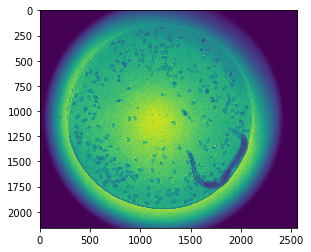

```python
# Take a look at the image before processing
from PIL import Image
image_path = '/Users/zplab/Desktop/VeraPythonScripts/vera_autofocus/microscope_images_3cat/test/1/19_0.png'
img = Image.open(image_path)
%matplotlib inline
imshow(np.asarray(img))
```

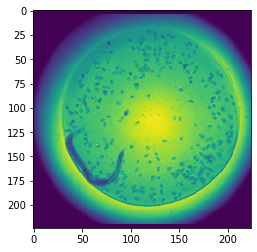

```python
image_path = '/Users/zplab/Desktop/VeraPythonScripts/vera_autofocus/microscope_images_3cat/test/1/19_0.png'
means = [0.485, 0.456, 0.406]
stds = [0.229, 0.224, 0.225]
transform = 'hflip'

# Process the image with a transform
tensor_image = process_image(image_path, means, stds, transform)

numpy_image = de_process_image(tensor_image, means, stds)

%matplotlib inline
from matplotlib.pyplot import imshow
imshow(numpy_image)
```

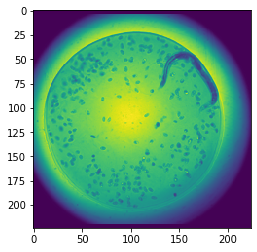

```python
image_path = '/Users/zplab/Desktop/VeraPythonScripts/vera_autofocus/microscope_images_3cat/test/1/19_0.png'
means = [0.485, 0.456, 0.406]
stds = [0.229, 0.224, 0.225]
transform = 'vflip'

# Process the image with a transform
tensor_image = process_image(image_path, means, stds, transform)

numpy_image = de_process_image(tensor_image, means, stds)

%matplotlib inline
from matplotlib.pyplot import imshow
imshow(numpy_image)
```

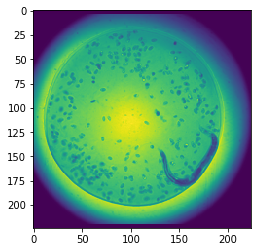

```python
# Test with no transform argument
image_path = '/Users/zplab/Desktop/VeraPythonScripts/vera_autofocus/microscope_images_3cat/test/1/19_0.png'
means = [0.485, 0.456, 0.406]
stds = [0.229, 0.224, 0.225]

# Process the image with a transform
tensor_image = process_image(image_path, means, stds)

numpy_image = de_process_image(tensor_image, means, stds)

%matplotlib inline
from matplotlib.pyplot import imshow
imshow(numpy_image)
```

```python
import torch
from torch.utils import data
from pathlib import Path
import os
import glob

class wormDataset(data.Dataset):
  'Characterizes a dataset for PyTorch'
  def __init__(self, file_path, means, stds, transform = None):
    # Assumes that the images are sorted by class into folders, which are named
    # with the class name
        self.file_path = Path(file_path)
        self.means = means
        self.stds = stds
        #Initialization
        self.classes = [] # Empty list to append class names onto
        self.transform = transform

        # Indexed list of class_folder/image.png
        #self.list_IDs = list_IDs
        self.image_paths = []

        # Find class folders on the file path
        for class_name in sorted(os.listdir(file_path)):
            # Use of sorted is important, numbered classes will import in order which is really helpful later

            # Exclude .DS_Store
            if class_name != '.DS_Store':

                # Save the class name to the classes list
                self.classes.append(class_name)

                # Make a Path to the class directory
                class_dir = self.file_path / class_name

                # Note that this is set to work with .png images and needs modification
                # to work with other types
                for image in class_dir.glob('*.png'):
                    # Add the path to the image to the list of image paths
                    self.image_paths.append(image)


  def __len__(self):
        'Denotes the total number of samples'
        return len(self.image_paths)

  def __getitem__(self, index):
        'Generates one sample of data'
        # Select sample

        # Needs a list with all the filenames in the list
        # Here, this is the name of the specific image + the enclosing class folder

        # Uses the index to get class_folder/image_name
        image_path = self.image_paths[index]

        # Load data and get label
        sample = process_image(image_path, self.means, self.stds, self.transform)

        # Convert the class folder into the string name of the class
        class_name = str(image_path.parent.stem)
        # Use this to convert the string name into the corresponding numerical label
        label = self.classes.index(class_name)

        return sample, label
```

```python
# Import all needed libraries
import matplotlib.pyplot as plt
import numpy as np
import torch
from torch import nn
from torch import optim
import torch.nn.functional as F
from torchvision import datasets, transforms, models
# These last two are used to save info about how the training progressed
import pickle
import datetime

# Set the full path to the main image directory
train_dir = '/Users/zplab/Desktop/VeraPythonScripts/vera_autofocus/microscope_images_3cat/train'
test_dir = '/Users/zplab/Desktop/VeraPythonScripts/vera_autofocus/microscope_images_3cat/test'
num_train = 10
num_test = 10

means = [0.485, 0.456, 0.406]
stds = [0.229, 0.224, 0.225]

traindata = wormDataset(train_dir, means, stds)
traindata_hflip = wormDataset(train_dir, means, stds, 'hflip')
traindata_vflip = wormDataset(train_dir, means, stds, 'vflip')

augmented_traindata = torch.utils.data.ConcatDataset([traindata, traindata_hflip, traindata_vflip])

# Should not agument the test data
testdata = wormDataset(test_dir, means, stds)

# Get the classes
class_names = augmented_traindata.datasets[0].classes
print('Detected ' + str(len(class_names)) + ' classes in training data')
print(class_names)

# Print out how many images are in the trainloader and testloader
print('Traindata length = ' + str(len(augmented_traindata)) + ', testdata length = ' + str(len(testdata)))
```

```
Detected 3 classes in training data
['0', '1', '2']
Traindata length = 13365, testdata length = 4455
```

Note the substantial increase in size of the training data

```python
# Load from the training and test sets
trainloader = torch.utils.data.DataLoader(augmented_traindata, batch_size=num_train, shuffle=True)
testloader = torch.utils.data.DataLoader(testdata, batch_size=num_test, shuffle=True)

# Print out how many images are in the trainloader and testloader
print("Train batch size = " + str(num_train) + ', test batch size = ' + str(num_test))
print('Trainloder length = ' + str(len(trainloader)) + ', testloader length = ' + str(len(testloader)))
```

```
Train batch size = 10, test batch size = 10
Trainloder length = 1337, testloader length = 446
```

```python
# Iterate through images in the train loader to see what labels (corresponding to classes) they have
label_dict = {}
for data in trainloader:
    images, labels = data
    for label in labels:
        # Convert the label into a number
        label = torch.Tensor.numpy(label)
        label = label.item()
        if label in label_dict:
            label_dict[label] += 1
        else:
            label_dict[label] = 1
label_dict
```

```
{0: 6513, 2: 6258, 1: 594}
```

The number of training samples is greatly increased, however, the imbalance between classes still remains. To address this, instantiate the worm dataset sampler to balance out the populations between classes.

```python
import torch
from torch.utils import data


class wormDatasetSampler(torch.utils.data.sampler.Sampler):
    """Samples elements randomly from a given list of indices for imbalanced dataset
    Arguments:
        indices (list, optional): a list of indices
        num_samples (int, optional): number of samples to draw

    To use the sampler, add an argument to the DataLoader sampler = wormDatasetSampler(wormDataset)
    This will pass the weights for the labels to the Dataloader
    Note that shuffle must be false, if shuffling is desired that needs to be part of the sampler
    """

    def __init__(self, dataset, indices=None, num_samples=None):

        # Make a set of indices to iterate through
        self.indices = list(range(len(dataset)))

        # Get the number of samples in the dataset
        self.num_samples = len(self.indices)

        # Make a dictionary with labels as keys and number of samples with that label as values
        label_to_count = {}
        for idx in self.indices:
            label = self._get_label(dataset, idx)
            if label in label_to_count:
                label_to_count[label] += 1
            else:
                label_to_count[label] = 1

        # weight for each sample
        weights = [1.0 / label_to_count[self._get_label(dataset, idx)]
                   for idx in self.indices]

        self.weights = torch.DoubleTensor(weights)
        # I think these weights are what is passed on to the DataLoader, presumably it knows what to do from there

    def _get_label(self, dataset, idx):
    	# Get the label from the dataset
        # In the wormDataset, each sample is a 1, 2 tensor with an array representing the image + the class
        # tensor[image_array, class_label]
        sample = dataset[idx]
        label = sample[1]
        return label

        #image_import.wormDataset

    def __iter__(self):

        # The sampler has to specify how to iterate through itself
        return (self.indices[i] for i in torch.multinomial(
            self.weights, self.num_samples, replacement=True))

    def __len__(self):
        return self.num_samples
```

```python
# Re-load the data, this time with the sampler enclosing the dataset
trainloader = torch.utils.data.DataLoader(augmented_traindata, sampler = wormDatasetSampler(augmented_traindata), batch_size=num_train, shuffle=False)
testloader = torch.utils.data.DataLoader(testdata, sampler = wormDatasetSampler(testdata), batch_size=num_test, shuffle=False)
# Shuffle has to be set to False when using a sampler. If you want shuffling it needs to happen in the sampler

# Print out how many images are in the trainloader and testloader
print("Train batch size = " + str(num_train) + ', test batch size = ' + str(num_test))
print('Trainloader length = ' + str(len(trainloader)) + ', testloader length = ' + str(len(testloader)))
```

```
Train batch size = 10, test batch size = 10
Trainloader length = 1337, testloader length = 446
```

```python
# Iterate through images in the train loader to see what labels (corresponding to classes) they have
label_dict = {}
for data in trainloader:
    images, labels = data
    for label in labels:
        # Convert the label into a number
        label = torch.Tensor.numpy(label)
        label = label.item()
        if label in label_dict:
            label_dict[label] += 1
        else:
            label_dict[label] = 1
label_dict
```

```
{1: 4559, 0: 4356, 2: 4450}
```

Now the number of samples in each dataset are much more similar. I do notice that the acceptable images has inceased from just under 600 to around 4500, an increase of 7.5. This means images might be repeated up to 7 times, which seems like it could introduce a risk of overfitting. The sampler code I based this sampler on is claimed to have been tested and not caused overfitting as a problem. I may revisit the logic of how many samples get repeated from the lower population class and try to shift it to rejecting slightly more from higher population than over-inflating the smaller population to this degree.

For this test, I reduced the size of the image data set so it would be more manageable. The practice dataset is much smaller but still has very different population sizes.

```python
from image_import import count_images

train_path = '/Users/zplab/Desktop/VeraPythonScripts/vera_autofocus/microscope_images_3cat/practice'
train_counts, class_names = count_images(train_path)
print(class_names)
print(train_counts)
```

```
['0', '1', '2']
[132, 8, 118]
```

```python
# Import all needed libraries
import matplotlib.pyplot as plt
import numpy as np
import torch
from torch import nn
from torch import optim
import torch.nn.functional as F
from torchvision import datasets, transforms, models
# These last two are used to save info about how the training progressed
import pickle
import datetime

from image_import import wormDataset, process_image

# Set the full path to the main image directory
train_dir = '/Users/zplab/Desktop/VeraPythonScripts/vera_autofocus/microscope_images_3cat/practice'
num_train = 10
num_test = 10

means = [0.485, 0.456, 0.406]
stds = [0.229, 0.224, 0.225]

traindata = wormDataset(train_dir, means, stds)
traindata_hflip = wormDataset(train_dir, means, stds, 'hflip')
traindata_vflip = wormDataset(train_dir, means, stds, 'vflip')

augmented_traindata = torch.utils.data.ConcatDataset([traindata, traindata_hflip, traindata_vflip])

# Get the classes
class_names = augmented_traindata.datasets[0].classes
print('Detected ' + str(len(class_names)) + ' classes in training data')
print(class_names)

# Print out how many images are in the trainloader and testloader
print('Traindata length = ' + str(len(augmented_traindata)))
```

```
Detected 3 classes in training data
['0', '1', '2']
Traindata length = 771
```

```python
import torch
from torch.utils import data


import torch
from torch.utils import data


class wormDatasetSampler(torch.utils.data.sampler.Sampler):
    # The usual sampler again so I can see it on the practice data

    def __init__(self, dataset, indices=None, num_samples=None):

        # Make a set of indices to iterate through
        self.indices = list(range(len(dataset)))

        # Get the number of samples in the dataset
        self.num_samples = len(self.indices)

        # Make a dictionary with labels as keys and number of samples with that label as values
        label_to_count = {}
        for idx in self.indices:
            label = self._get_label(dataset, idx)
            if label in label_to_count:
                label_to_count[label] += 1
            else:
                label_to_count[label] = 1

        # weight for each sample
        weights = [1.0 / label_to_count[self._get_label(dataset, idx)]
                   for idx in self.indices]

        self.weights = torch.DoubleTensor(weights)
        # I think these weights are what is passed on to the DataLoader, presumably it knows what to do from there

    def _get_label(self, dataset, idx):
    	# Get the label from the dataset
        # In the wormDataset, each sample is a 1, 2 tensor with an array representing the image + the class
        # tensor[image_array, class_label]
        sample = dataset[idx]
        label = sample[1]
        return label

        #image_import.wormDataset

    def __iter__(self):

        # The sampler has to specify how to iterate through itself
        return (self.indices[i] for i in torch.multinomial(
            self.weights, self.num_samples, replacement=True))

    def __len__(self):
        return self.num_samples
```

```python
# Re-load the data, this time with the sampler enclosing the dataset
trainloader = torch.utils.data.DataLoader(augmented_traindata, sampler = wormDatasetSampler(augmented_traindata), batch_size=num_train, shuffle=False)
# Shuffle has to be set to False when using a sampler. If you want shuffling it needs to happen in the sampler

# Print out how many images are in the trainloader and testloader
print("Train batch size = " + str(num_train))
print('Trainloader length = ' + str(len(trainloader)))
```

```
Train batch size = 10
Trainloader length = 78
```

```python
from image_import import count_loader_samples
label_dict = count_loader_samples(trainloader)
label_dict
```

```
{0: 260, 2: 279, 1: 232}
```

There are only 8 samples in class 1. Augmentation by flipping can increase this to 24, but after sampling there are now 232 samples! This is too much to feel confident that overfitting won't be a problem.

Make some changes to the dataset sampler to prevent duplicating samples so much

```python
import torch
from torch.utils import data

class wormDatasetSampler(torch.utils.data.sampler.Sampler):
# Randomly samples from the dataset. Pulls fewer images from classes with a large number of samples and duplicates
# some samples from classes with a small number of samples to even out the number of samples per class and
# prevent bias in training.
# This code is heavily based on this repo: https://github.com/ufoym/imbalanced-dataset-sampler
# Most modifications are so it will work with the wormDataset
# Arguments:
#   dataset: Pytorch dataset object containing samples to load. Assumes created with wormDataset
# Returns:
#   Dataloader object that can be used for training models in Pytorch
# Syntax for using the sampler:
#   trainloader = torch.utils.data.DataLoader(traindata, sampler = wormDatasetSampler(traindata), batch_size=num_train, shuffle=False)
#   Note that shuffle has to be False since shuffling is now being directed by the sampler.

    def __init__(self, dataset, indices=None):

        # Make a set of indices to iterate through
        self.indices = list(range(len(dataset)))


        # Don't replace samples - samples have already been agumented, take one that isn't in the set already
        self.replacement = False

        # Make a dictionary with labels as keys and number of samples with that label as values
        label_to_count = {}
        for idx in self.indices:
            label = self._get_label(dataset, idx)
            if label in label_to_count:
                label_to_count[label] += 1
            else:
                label_to_count[label] = 1

        # weight for each sample
        weights = [1.0 / label_to_count[self._get_label(dataset, idx)]
                   for idx in self.indices]
        self.weights = torch.DoubleTensor(weights)

        # Limit the number of samples to 3x the smallest population
        min_pop = 1000000
        for label in label_to_count:
            if label_to_count[label] < min_pop:
                min_pop = label_to_count[label]
        self.num_samples = 3 * min_pop



    def _get_label(self, dataset, idx):
    	# Get the label from the dataset
        # In the wormDataset, each sample is a 1, 2 tensor with an array representing the image + the class
        # tensor[image_array, class_label]
        sample = dataset[idx]
        label = sample[1]
        return label

        #image_import.wormDataset

    def __iter__(self):

        # The sampler has to specify how to iterate through itself
        return (self.indices[i] for i in torch.multinomial(
            self.weights, self.num_samples, replacement=True))

    def __len__(self):
        return self.num_samples
```

```python
# Re-load the data, this time with the sampler enclosing the dataset
trainloader = torch.utils.data.DataLoader(augmented_traindata, sampler = wormDatasetSampler(augmented_traindata), batch_size=num_train, shuffle=False)
# Shuffle has to be set to False when using a sampler. If you want shuffling it needs to happen in the sampler

# Print out how many images are in the trainloader and testloader
print("Train batch size = " + str(num_train))
print('Trainloader length = ' + str(len(trainloader)))
```

```
Train batch size = 10
Trainloader length = 7
```

```python
from image_import import count_loader_samples
label_dict = count_loader_samples(trainloader)
label_dict
```

```
{1: 18, 0: 23, 2: 22}
```